# Observational Analysis: Estimate Visualization

Julian Frattini

2025-03-05

This notebook visualizes the distributions of the coefficients for each factor and each response variable metric involved in the observational studies. The observational study currently involves the following metrics.

```r
metrics <- c("Precision", "Recall", "F1", "F2", "AP")
```

## Data Preparation

First, load the respective data. Every observational analysis produced one such file per response variable metric.

```r
d.precision <- read.csv(file.path(path.data, "obs-precision.csv"))
d.recall <- read.csv(file.path(path.data, "obs-recall.csv"))
d.f1 <- read.csv(file.path(path.data, "obs-f1.csv"))
d.f2 <- read.csv(file.path(path.data, "obs-f2.csv"))
d.ap <- read.csv(file.path(path.data, "obs-ap.csv"))
```

Then, define a function that calculates the 95% and 50% confidence interval from the mean and variance.

```r
calculate_ci <- function(df) {
  return(df %>% mutate(
    ci1.low = mean - 2*var,
    ci1.up = mean + 2*var,
    ci2.low = mean - var,
    ci2.up = mean + var
  ))
}

d.precision <- calculate_ci(d.precision)
d.recall <- calculate_ci(d.recall)
d.f1 <- calculate_ci(d.f1)
d.f2 <- calculate_ci(d.f2)
d.ap <- calculate_ci(d.ap)
```

Add the response variable metric as a column in each data frame.

```r
d.precision$resp = "Precision"
d.recall$resp = "Recall"
d.f1$resp = "F1"
d.f2$resp = "F2"
d.ap$resp = "AP"
```

Finally, combine the individual datasets to one and cast the response variable column `resp` to an ordered factor such that it is displayed sequentially.

```r
d <- rbind(d.precision, d.recall, d.f1, d.f2, d.ap)

d <- d %>%
  mutate(resp = factor(d$resp, levels = metrics, ordered = TRUE)) %>%
  mutate(resp = fct_rev(resp))
```

The `forcats::fct_rev` is necessary since horizontal errorbars with a `color` aesthetic will show the factor levels in reverse order otherwise.

## Data Visualization

Visualize the coefficients in an errorbar plot.

```r
dodge = 0.8 # distance between errorbars of each metric

ci1.width = 0.6 # size of the whiskers of the outer confidence interval
ci2.width = 0.6 # size of the whiskers of the inner confidence interval

ci1.thic = 0.7 # thickness of the outer confidence interval
ci2.thic = 1.2 # thickness of the inner confidence interval
```

### Full Visualization

The first figure displays the coefficient distributions of all factors, regardless of their significance.

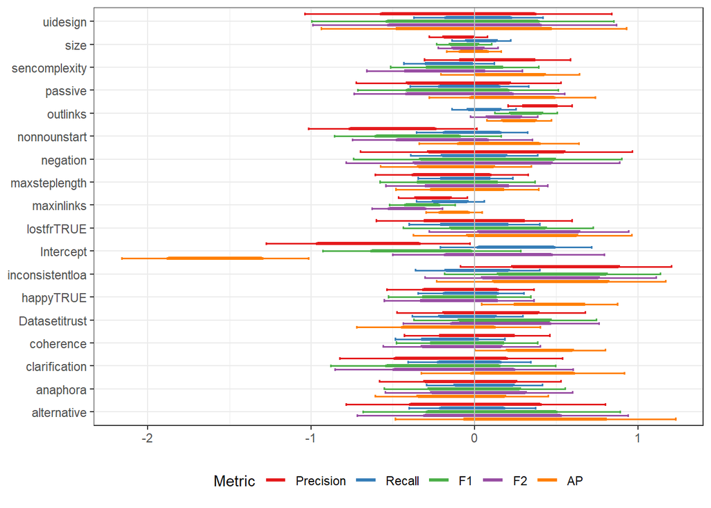

```r
d %>%
  ggplot(aes(x=coef, color=resp)) +
  geom_errorbar(aes(ymin = ci1.low, ymax = ci1.up), width=ci1.width, linewidth=ci1.thic, position=position_dodge(width=dodge)) +
  geom_errorbar(aes(ymin = ci2.low, ymax = ci2.up), width=ci2.width, linewidth=ci2.thic, position=position_dodge(width=dodge)) +
  coord_flip() +
  geom_hline(yintercept=0, color = "grey") +
  theme_bw() +
    theme(
      axis.title.y=element_blank(), # remove the label of the y axis
      legend.position = "bottom") + # place the legend of the color aesthetic below the plot
    # axis labels
    labs(color = "Metric", x = "Posterior coefficient distribution") +
    scale_color_manual(values = brewer.pal(n = 5, name = "Set1"), limits=metrics)
```

```r
ggsave(
  file = file.path(path.figures, "obs-coefs-full.pdf"), device = "pdf",
  width = 16, height = 28, units = "cm")
```

### Significant Visualization

For better understandability, also create a visualization only involving the significant factors. A factor is considered significant if any of the metric distributions has a inner confidence interval that is not consistent with 0.

```r
significant_coefs <- d %>%
  filter(coef != "Intercept") %>% # ignore the Intercept coefficient
  mutate(significant = !(ci2.low < 0 & ci2.up > 0)) %>% # determine a coefficient as significant if the inner (50%) confidence interval does not overlap with zero
  group_by(coef) %>% # group by coefficient
  summarize(contains_significant = (sum(significant)>0)) %>% # determine all coefficients where at least one of the measured metrics is significant
  filter(contains_significant) # keep only these coefficients
```

For better readability, create a mapping between the names of the variables (as in the column names) and the more literal names of the factors.

```r
factor.names <- c(
  "size" = "Large Use Case",
  "maxinlinks" = "Scattered Requirements",
  "outlinks" = "Tangled Requirements",
  "nonnounstart" = "Starts without Noun Phrase",
  "inconsistentloa" = "Inconsistent Level of Abstraction",
  "lostfrTRUE" = "Mislocated Functional Requirement",
  "happyTRUE" = "Happy Use Case",
  "coherence" = "Coherent",
  "sencomplexity" = "Sentence Level Complexity"
)

factor.order <- c("Large Use Case", "Scattered Requirements", "Tangled Requirements", "Starts without Noun Phrase", "Inconsistent Level of Abstraction", "Mislocated Functional Requirement", "Happy Use Case", "Coherent", "Sentence Level Complexity")
```

Display the significant factors.

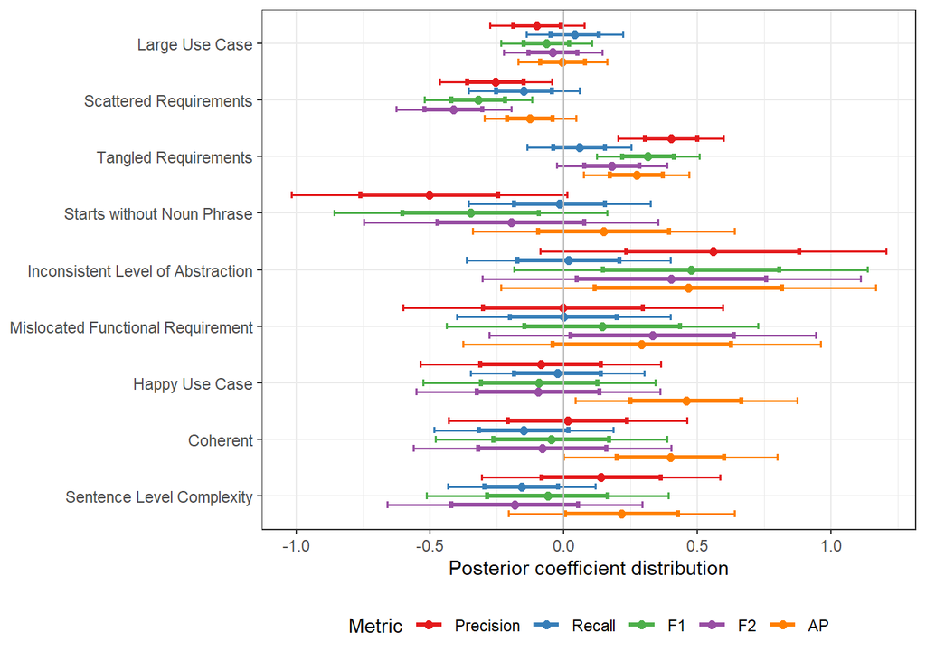

```r
d %>%
  filter(coef %in% significant_coefs$coef) %>% # filter out all non-significant coefficients
  mutate(name = recode(coef, !!!factor.names)) %>% # replace all variable names with readable factor names
  ggplot(aes(y=factor(name, levels=factor.order, ordered = TRUE), color=resp)) +
    # mean value
    geom_point(aes(x = mean), position=position_dodge(width=dodge), size = 2) +
    # error bar for the "outer" confidence interval
    geom_errorbar(
      aes(xmin = ci1.low, xmax = ci1.up),
      width=ci1.width, linewidth=ci1.thic,
      position=position_dodge(width=dodge)) +
    # error bar for the "inner" confidence interval
    geom_errorbar(
      aes(xmin = ci2.low, xmax = ci2.up),
      width=ci2.width, linewidth=ci2.thic,
      position=position_dodge(width=dodge)) +
    # vertical line around 0 to show the threshold for significance
    geom_vline(xintercept=0, color = "grey") +
    theme_bw() +
    theme(
      axis.title.y=element_blank(), # remove the label of the y axis
      legend.position = "bottom") + # place the legend of the color aesthetic below the plot
    # axis labels
    labs(color = "Metric", x = "Posterior coefficient distribution") +
    scale_color_manual(values = brewer.pal(n = 5, name = "Set1"), limits=metrics) +
    scale_y_discrete(limits = rev) #+
```

```r
    #scale_color_discrete(limits = metrics, labels = c("Precision", "Recall", "F1", "F2", "AP"))
```

```r
ggsave(
  file = file.path(path.figures, "obs-coefs-sig.pdf"), device = "pdf",
  width = 24, height = 18, units = "cm")
```